$$ \begin{aligned} \begin{cases} a_{11} x_1 + a_{12} x_2 + \cdots + a_{1n} x_n = b_1\\ a_{21} x_2 + a_{22} x_2 + \cdots + a_{2n} x_n = b_2\\ \vdots\quad\quad\quad \vdots\quad\quad\quad \vdots\quad\quad\quad \\ a_{n1} x_1 + a_{n2} x_2 + \cdots + a_{nn} x_n = b_n \end{cases} \to \begin{bmatrix} a_{11} & a_{12} & \cdots & a_{1n}\\ a_{21} & a_{22} & \cdots & a_{2n}\\ \vdots & \vdots &\ddots &\vdots\\ a_{n1} & a_{n2} & \cdots & a_{nn} \end{bmatrix} \begin{bmatrix} x_1\\ x_2 \\ \vdots \\ x_n \end{bmatrix} = \begin{bmatrix} b_1 \\ b_2 \\ \vdots \\ b_n \end{bmatrix} \to \mathbf{A} \vec{x} = \vec{B} \end{aligned} $$

# 기본 개념

## 행렬의 종류

정방행렬

- 미지수의 개수와 방정식의 개수가 동일한 연립방정식에 해당

삼각행렬

- 대각선 항을 기준으로 위나 아래만 0이 아닌 수가 있는 행렬
- 위쪽에 값이 있으면 상삼각행렬, 아래쪽에 값이 있으면 하삼각행렬

대각행렬

- 대각선상에 있지 않은 모든 원소가 0이면 대각행렬이다.

단위행렬

- 대각행렬 중 대각원소가 모두 1인 행렬
- 주로 $\mathbf{I}$로 표기

**Tridiagonal Matrix(삼대각행렬)**

- Banded Matrix라고도 한다.
- 대각원소들과 그 위, 아래로 인접한 원소들만 0이 아닌 행렬

$$ \begin{bmatrix} a_{11} & a_{12} &\cdots & 0 \\ a_{21} & a_{22} &\cdots & 0 \\ \vdots & \vdots &\ddots & a_{(n-1)n} &\\ 0 & 0 & a_{n(n-1)} & a_{nn} \end{bmatrix} $$

## 행렬 연산

**행렬의 덧셈**

- 동일한 위치의 원소끼리 더한다.
- 뺄셈도 음수의 덧셈과 같이 계산한다.
  - 행렬에 음수 기호를 붙이면 내부 원소 모두에 음수 기호가 추가된다.

$$ \mathbf{A} + \mathbf{B} = a_{ij}+b_{ij}=c_{ij} $$

**행렬의 곱셈**

$$ \begin{aligned} \mathbf{A} = \begin{bmatrix} a_{11} & a_{12} & a_{13} \\ a_{21} & a_{22} & a_{23} \end{bmatrix} = \begin{bmatrix} 2 & 1 & 3 \\ -1 & 2 & 4 \end{bmatrix} , \mathbf{B}= \begin{bmatrix} b_{11} & b_{12}\\ b_{21} & b_{22} \\ b_{31} & b_{32} \\ \end{bmatrix} = \begin{bmatrix} 1 & 2\\ 2 & -1 \\ 3 & 4 \\ \end{bmatrix} \end{aligned} \\ \begin{aligned} \mathbf{A} \times \mathbf{B} = \begin{bmatrix} a_{11}b_{11} + a_{12}b_{21} + a_{13}b_{31} & a_{11}b_{12} + a_{12}b_{22} + a_{13}b_{32}\\ a_{21}b_{11} + a_{22}b_{21} + a_{23}b_{31} & a_{21}b_{12} + a_{22}b_{22} + a_{23}b_{32} \end{bmatrix} = \begin{bmatrix} 13 & 15 \\ 15 & 12 \end{bmatrix} \end{aligned} $$

$$ \bf{A}_{n\times m} \times \bf{B}_{m\times n} = \bf{C}_{n \times n} $$

```python
import numpy as np

A = np.array([
    [2, 1, 3],
    [-1, 2, 4]
])
B = np.array([
    [1,2],
    [2,-1],
    [3,4]
])

np.matmul(A,B)
```

```
array([[13, 15],
       [15, 12]])
```

**역행렬**

- 원래 행렬과 곱하면 단위행렬이 나오는 행렬 $$ \bf{A}_{n\times n} \to \bf{A}_{n\times_n}^{-1} $$ $$ \bf{A}_{n\times n} \times \bf{A}_{n\times_n}^{-1} = \bf{I} $$

$$ \mathbf{A}\vec{x}=\vec{B} \to \mathbf{A^{-1}}\mathbf{A}\vec{x}=\mathbf{A^{-1}}\vec{B} \\ = \mathbf{I}\vec{x} = \mathbf{A^{-1}}\vec{B} \to \vec{x}=\mathbf{A^{-1}}\vec{B} $$

**전치행렬(Transpose Matrix)**

- 행과 열을 바꾼 것 $$ \begin{aligned} \bf{A} = \begin{bmatrix} 4&3&1 \\ 2&1&5 \end{bmatrix} \bf{A}^T = \begin{bmatrix} 4&2\\ 3&1\\ 1&5 \end{bmatrix} \end{aligned} $$

**Determinant(행렬식)**

- 행렬 $\bf{A}$가 정방행렬일 때만 정의된다.
- 일반적으로 $\det(\bf{A})$ 또는 $|\bf{A}|$로 표기한다.

$$ \begin{aligned} |\bf{A}| = \begin{bmatrix} a_{11}&a_{12}&a_{13}\\ a_{21}&a_{22}&a_{23}\\ a_{31}&a_{32}&a_{33} \end{bmatrix} =a_{11}(-1)^{1+1} \begin{vmatrix} a_{22} & a_{23}\\ a_{32} & a_{33} \end{vmatrix} +a_{12}(-1)^{1+2} \begin{vmatrix} a_{21} & a_{23}\\ a_{31} & a_{33} \end{vmatrix} +a_{13}(-1)^{1+3} \begin{vmatrix} a_{21} & a_{22}\\ a_{31} & a_{32} \end{vmatrix} \end{aligned} $$

**Cramer's Rule**

- $x_k = \frac{\det{\bf{A}_k}}{\det{\bf{A}}}$
- $\text{where }\bf{A}_k =\bf{A}$에서 $k$번째 열의 원소를 $\vec{B}$의 원소들로 대체한 행렬 $$ \bf{A}_{n\times n}\vec{x}=\vec{B} $$

# 선형연립방정식의 수치해법

교재 89p

## 가우스 소거법

$$ \begin{aligned} \begin{cases} a_{11}x_1 + a_{12}x_2 + a_{13}x_3 = r_1 \\ a_{21}x_1 + a_{22}x_2 + a_{23}x_3 = r_2 \\ a_{31}x_1 + a_{32}x_2 + a_{33}x_3 = r_3 \\ \end{cases} \to \begin{bmatrix} a_{11}&a_{12}&a_{13}\\ a_{21}&a_{22}&a_{23} \\ a_{31}&a_{32}&a_{33}\\ \end{bmatrix} \begin{bmatrix} x_1\\ x_2\\ x_3 \end{bmatrix} = \begin{bmatrix} r_1\\ r_2\\ r_3 \end{bmatrix} \end{aligned} $$

**기초 행 연산**

- 연립방정식 중 하나에 임의의 상수를 곱해도 해는 변하지 않는다.
- 연립방정식끼리 빼도 해는 변하지 않는다.
- 연립방정식 중 하나에 임의의 상수를 곱해서 다른 방정식에서 빼도 해는 변하지 않는다.

$$ a_{21}[x_1 + a_{12}/a_{11}x_2 + a_{13}/a_{11}x_3 = r_1/a_{11}] \\ (-a_{21}+a_{21})x_1 + (a_{22} -(a_{12}/a_{11})a_{21})x_2 + (a_{23}-(a_{13}/a_{11})a_21)x_3 = -1/a_{11}a_{21}r_1 + r_2\\ \vdots $$

$$ \begin{aligned} \begin{bmatrix} 1&\frac{a_{12}}{a_{11}}&\frac{a_{13}}{a_{11}}\\ (a_{21}-a_{21}) & a_{22} - \frac{a_{12}}{a_{11}}a_{21} & a_{23}-\frac{a_{13}}{a_{11}}a_{21}\\ a_{31}&a_{32}&a_{33} \end{bmatrix} \begin{bmatrix} x_1\\x_2\\x_3 \end{bmatrix} = \begin{bmatrix} \frac{r_1}{a_{11}}\\ -\frac{a_{21}}{a_{11}}r_1 + r_2\\ r_3 \end{bmatrix} \end{aligned} $$

이를 반복하여 하삼각행렬을 전부 0으로, 대각원소를 모두 1로 만들면 맨 아래 행에는 계수가 1만 남아 대입을 통해 쉽게 해를 구할 수 있다.

$$ \begin{aligned} \begin{bmatrix} 1&a_{12}&a_{13}\\0&1&a_{23}\\0&0&1 \end{bmatrix} \begin{bmatrix} x_1\\x_2\\x_3 \end{bmatrix} = \begin{bmatrix} r_1'\\r_2'\\r_3' \end{bmatrix} \end{aligned} $$

$$ \begin{cases} x_1 + a_{12}'x_2 + a_{13}'x_3 = r_1'\\ x_2 + aa_{23}'x_3 = r_2'\\ x_3 = r_3' \end{cases} $$

$x_3=r_3'$으로 결정되었으므로 나머지도 다 구할 수 있게 된다.

이것이 **가우스 소거법(Gauss Elimination)** 이다.

## 가우스-조던 소거법

*Gause-Jordan Elimination*

하삼각 행렬만 0으로 만들지 말고 상삼각 행렬도 전부 다 0으로 만든다.

$$ \begin{aligned} \begin{bmatrix} 1&0&0\\0&1&0\\0&0&1 \end{bmatrix} \begin{bmatrix} x_1\\x_2\\x_3 \end{bmatrix} = \begin{bmatrix} r_1''\\r_2''\\r_3'' \end{bmatrix} \end{aligned} $$

연립방정식으로 다시 전환하면 그냥 바로 값을 대입하면 해가 된다.

### 교재 예제 II-3-1

$$ \begin{aligned} \begin{bmatrix} 2&1&-1\\1&4&1\\2&1&3 \end{bmatrix} \begin{bmatrix} x_1\\x_2\\x_3 \end{bmatrix} = \begin{bmatrix} 1\\12\\13 \end{bmatrix} \end{aligned} $$

C 코드에선 확장행렬(Augmented Matrix)로 입력해야 한다.

$$ \begin{bmatrix} 2&1&-1&1\\1&4&1&12\\2&1&3&13 \end{bmatrix} $$

```python
import numpy as np
from Linear_Equation import Linear_Equation

A = np.array([[2,1,-1],[1,4,1],[2,1,3]])
B = np.array([[1],[12],[13]])
augmented_matrix = np.hstack([A, B])

x, logs = Linear_Equation(augmented_matrix).Gauss_Jordan()

print('x=',x)
print('\n'.join(logs))
```

```
x= [1. 2. 3.]
Step 1: Normalize row 0:
[[ 1.   0.5 -0.5  0.5]
 [ 1.   4.   1.  12. ]
 [ 2.   1.   3.  13. ]]
Step 1.1: Eliminating row 1, factor = 1.0:
[[ 1.   0.5 -0.5  0.5]
 [ 0.   3.5  1.5 11.5]
 [ 2.   1.   3.  13. ]]
Step 1.2: Eliminating row 2, factor = 2.0:
[[ 1.   0.5 -0.5  0.5]
 [ 0.   3.5  1.5 11.5]
 [ 0.   0.   4.  12. ]]
Step 2: Normalize row 1:
[[ 1.          0.5        -0.5         0.5       ]
 [ 0.          1.          0.42857143  3.28571429]
 [ 0.          0.          4.         12.        ]]
Step 2.0: Eliminating row 0, factor = 0.5:
[[ 1.          0.         -0.71428571 -1.14285714]
 [ 0.          1.          0.42857143  3.28571429]
 [ 0.          0.          4.         12.        ]]
Step 2.2: Eliminating row 2, factor = 0.0:
[[ 1.          0.         -0.71428571 -1.14285714]
 [ 0.          1.          0.42857143  3.28571429]
 [ 0.          0.          4.         12.        ]]
Step 3: Normalize row 2:
[[ 1.          0.         -0.71428571 -1.14285714]
 [ 0.          1.          0.42857143  3.28571429]
 [ 0.          0.          1.          3.        ]]
Step 3.0: Eliminating row 0, factor = -0.7142857142857143:
[[1.         0.         0.         1.        ]
 [0.         1.         0.42857143 3.28571429]
 [0.         0.         1.         3.        ]]
Step 3.1: Eliminating row 1, factor = 0.42857142857142855:
[[1. 0. 0. 1.]
 [0. 1. 0. 2.]
 [0. 0. 1. 3.]]
```

```
x0 = 1.000000
x1 = 2.000000
x2 = 3.000000
```

### 교재 예제 II-3-2

```
double x[4];
   double A[4][5]={{4.0,3.0,3.0,3.0,13.0},{5.0,6.0,5.0,5.0,21.0}
                  ,{6.0,7.0,7.0,6.0,26.0},{7.0,6.0,7.0,8.0,28.0}};
x0=1.000000
x1=1.000000
x2=1.000000
x3=1.000000
```

### 교재 예제 II-3-3

```
double x[3];
   double A[3][4]={{2.0,1.0,-1.0,1.0},{1.0,4.0,1.0,12.0},{2.0,1.0,3.0,13.0}};
```

```
x0=1.000000
x1=2.000000
x2=3.000000
```

```python
A = np.array([[2,1,-1],[1,4,1],[2,1,3]])
B = np.array([[1], [12], [13]])
augmented_matrix = np.hstack([A, B])
x, logs = Linear_Equation(augmented_matrix).Gauss_Jordan()

print('x=',x)
print('\n'.join(logs))
```

```
x= [1. 2. 3.]
Step 1: Normalize row 0:
[[ 1.   0.5 -0.5  0.5]
 [ 1.   4.   1.  12. ]
 [ 2.   1.   3.  13. ]]
Step 1.1: Eliminating row 1, factor = 1.0:
[[ 1.   0.5 -0.5  0.5]
 [ 0.   3.5  1.5 11.5]
 [ 2.   1.   3.  13. ]]
Step 1.2: Eliminating row 2, factor = 2.0:
[[ 1.   0.5 -0.5  0.5]
 [ 0.   3.5  1.5 11.5]
 [ 0.   0.   4.  12. ]]
Step 2: Normalize row 1:
[[ 1.          0.5        -0.5         0.5       ]
 [ 0.          1.          0.42857143  3.28571429]
 [ 0.          0.          4.         12.        ]]
Step 2.0: Eliminating row 0, factor = 0.5:
[[ 1.          0.         -0.71428571 -1.14285714]
 [ 0.          1.          0.42857143  3.28571429]
 [ 0.          0.          4.         12.        ]]
Step 2.2: Eliminating row 2, factor = 0.0:
[[ 1.          0.         -0.71428571 -1.14285714]
 [ 0.          1.          0.42857143  3.28571429]
 [ 0.          0.          4.         12.        ]]
Step 3: Normalize row 2:
[[ 1.          0.         -0.71428571 -1.14285714]
 [ 0.          1.          0.42857143  3.28571429]
 [ 0.          0.          1.          3.        ]]
Step 3.0: Eliminating row 0, factor = -0.7142857142857143:
[[1.         0.         0.         1.        ]
 [0.         1.         0.42857143 3.28571429]
 [0.         0.         1.         3.        ]]
Step 3.1: Eliminating row 1, factor = 0.42857142857142855:
[[1. 0. 0. 1.]
 [0. 1. 0. 2.]
 [0. 0. 1. 3.]]
```

### 교재 예제 II-3-4

```
double x[4];
   double A[4][5]={{4.0,3.0,3.0,3.0,13.0},{5.0,6.0,5.0,5.0,21.0}
                  ,{6.0,7.0,7.0,6.0,26.0},{7.0,6.0,7.0,8.0,28.0}};
```

```
x0=1.000000
x1=1.000000
x2=1.000000
x3=1.000000
```

```python
import numpy as np

A = np.array([
    [4,3,3,3],
    [5,6,5,5],
    [6,7,7,6],
    [7,6,7,8]
])
B = np.array([
    [13],
    [21],
    [26],
    [28]
])
augmented_matrix = np.hstack([A, B])
x, logs = Linear_Equation(augmented_matrix).Gauss_Jordan()

print('x=',x)
print('\n'.join(logs))
```

```
x= [1. 1. 1. 1.]
Step 1: Normalize row 0:
[[ 1.    0.75  0.75  0.75  3.25]
 [ 5.    6.    5.    5.   21.  ]
 [ 6.    7.    7.    6.   26.  ]
 [ 7.    6.    7.    8.   28.  ]]
Step 1.1: Eliminating row 1, factor = 5.0:
[[ 1.    0.75  0.75  0.75  3.25]
 [ 0.    2.25  1.25  1.25  4.75]
 [ 6.    7.    7.    6.   26.  ]
 [ 7.    6.    7.    8.   28.  ]]
Step 1.2: Eliminating row 2, factor = 6.0:
[[ 1.    0.75  0.75  0.75  3.25]
 [ 0.    2.25  1.25  1.25  4.75]
 [ 0.    2.5   2.5   1.5   6.5 ]
 [ 7.    6.    7.    8.   28.  ]]
Step 1.3: Eliminating row 3, factor = 7.0:
[[1.   0.75 0.75 0.75 3.25]
 [0.   2.25 1.25 1.25 4.75]
 [0.   2.5  2.5  1.5  6.5 ]
 [0.   0.75 1.75 2.75 5.25]]
Step 2: Normalize row 1:
[[1.         0.75       0.75       0.75       3.25      ]
 [0.         1.         0.55555556 0.55555556 2.11111111]
 [0.         2.5        2.5        1.5        6.5       ]
 [0.         0.75       1.75       2.75       5.25      ]]
Step 2.0: Eliminating row 0, factor = 0.75:
[[1.         0.         0.33333333 0.33333333 1.66666667]
 [0.         1.         0.55555556 0.55555556 2.11111111]
 [0.         2.5        2.5        1.5        6.5       ]
 [0.         0.75       1.75       2.75       5.25      ]]
Step 2.2: Eliminating row 2, factor = 2.5:
[[1.         0.         0.33333333 0.33333333 1.66666667]
 [0.         1.         0.55555556 0.55555556 2.11111111]
 [0.         0.         1.11111111 0.11111111 1.22222222]
 [0.         0.75       1.75       2.75       5.25      ]]
Step 2.3: Eliminating row 3, factor = 0.75:
[[1.         0.         0.33333333 0.33333333 1.66666667]
 [0.         1.         0.55555556 0.55555556 2.11111111]
 [0.         0.         1.11111111 0.11111111 1.22222222]
```

[output cut: 26 more lines]

```
Step 4.0: Eliminating row 0, factor = 0.3:
[[1.  0.  0.  0.  1. ]
 [0.  1.  0.  0.5 1.5]
 [0.  0.  1.  0.1 1.1]
 [0.  0.  0.  1.  1. ]]
Step 4.1: Eliminating row 1, factor = 0.5:
[[1.  0.  0.  0.  1. ]
 [0.  1.  0.  0.  1. ]
 [0.  0.  1.  0.1 1.1]
 [0.  0.  0.  1.  1. ]]
Step 4.2: Eliminating row 2, factor = 0.10000000000000003:
[[1. 0. 0. 0. 1.]
 [0. 1. 0. 0. 1.]
 [0. 0. 1. 0. 1.]
 [0. 0. 0. 1. 1.]]
```

### Chapra Ch.8 8.3 CASE STUDY

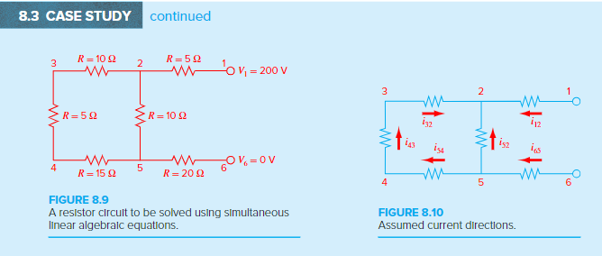

$$ \text{Currents}\\ \begin{cases} i_{12}+i_{52}+i_{32}=0\\ i_{65}-i_{52}-i_{54}=0\\ i_{43}-i_{32}=0\\ i_{54}-i_{43}=0 \end{cases} $$

$$ \text{Voltages}\\ \begin{cases} -i_{54}R_{54}-i_{43}R_{43}-i_{32}R_{32}+i_{52}R_{52}=0\\ -i_{65}R_{65}- i_{52}R_{52} + i_{12}R_{12} -200 =0 \end{cases} $$

$$ \begin{aligned} \begin{bmatrix} 1&1&1&0&0&0\\ 0&-1&0&1&-1&0\\ 0&0&-1&0&0&1\\ 0&0&0&0&1&-1\\ 0&10&-10&0&-15&-5\\ 5&-10&0&-20&0&0 \end{bmatrix} \begin{bmatrix} i_{12}\\i_{52}\\i_{32}\\i_{65}\\i_{54}\\i_{43} \end{bmatrix} = \begin{bmatrix} 0\\0\\0\\0\\0\\200 \end{bmatrix} \end{aligned} $$

```python
import numpy as np
A = np.array([
    [1,1,1,0,0,0],
    [0,-1,0,1,-1,0],
    [0,0,-1,0,0,1],
    [0,0,0,0,1,-1],
    [0,10,-10,0,-15,-5],
    [5,-10,0,-20,0,0]
])
B = np.array([0,0,0,0,0,200]).reshape(-1,1)
augmented_matrix = np.hstack([A, B])
x, logs = Linear_Equation(augmented_matrix).Gauss_Jordan()

print('x=',x)
print('\n'.join(logs))
```

```
---------------------------------------------------------------------------
ZeroDivisionError                         Traceback (most recent call last)
Cell In[5], line 12
     10 B = np.array([0,0,0,0,0,200]).reshape(-1,1)
     11 augmented_matrix = np.hstack([A, B])
---> 12 x, logs = Linear_Equation(augmented_matrix).Gauss_Jordan()
     14 print('x=',x)
     15 print('\n'.join(logs))

File c:\Users\USER\OneDrive\바탕 화면\2024_2학기\수치해석\강의노트\Linear_Equation.py:69, in Linear_Equation.Gauss_Jordan(self)
     67 for j in range(n):
     68     if augmented_matrix[j, j] == 0:
---> 69         raise ZeroDivisionError("Pivot element is zero. The system cannot be solved.")
     70     augmented_matrix[j] /= augmented_matrix[j, j]
     71     logs.append(f"Step {j+1}: Normalize row {j}:\n{augmented_matrix}")

ZeroDivisionError: Pivot element is zero. The system cannot be solved.
```

원래 행렬을 그대로 가우스 소거법 프로그램에 넣으면 대각선 항에 0이 들어가 계산이 안된다. 행을 바꿔야 한다.

```
double x[6];
   double A[6][7]={
    {1,1,1,0,0,0,0},
    {0,-1,0,1,-1,0,0},
    {0,0,-1,0,0,1,0},
    {0,10,-10,0,-15,-5,0},
    {5,-10,0,-20,0,0,200},
    {0,0,0,0,1,-1,0}
   };


main()
{
    int i,j,k,n;
    double c,sum;
    n=5;
```

```
x0=6.153846
x1=-4.615385
x2=-1.538462
x3=-6.153846
x4=-1.538462
x5=-1.538462
```

음수는 전류의 방향을 나타내는 것이다.

## Banded Matrix or Tri-Diagonal Matrix Solving

교재 103페이지

n개의 미지수, n개의 방정식 전제

$$ \begin{aligned} \begin{cases} b_1x_1 + c_1x_2=r_1 \\ a_2x_1 + b_2x_2 + c_2x_3 = r_2\\ \vdots\\ a_{n-1}x_{n-2} + b_{n-1}x_{n-1} + c_{n-1}x_{n} = r_{n-1}\\ a_nx_{n-1}+b_nx_n =r_n \end{cases} \to \begin{bmatrix} b_1&c_1&0&\cdots & 0\\ a_2&b_2&c_2&\cdots & 0\\ \vdots&\vdots&\vdots&\ddots&\vdots\\ 0&\cdots&a_{n-1}&b_{n-1}&c_{n-1}\\ 0&\cdots&\cdots&a_n&b_n \end{bmatrix} \begin{bmatrix} x_1\\x_2\\ \vdots\\ x_{n-1}\\ x_n \end{bmatrix} = \begin{bmatrix} r_1 \\ r_2 \\ \vdots \\ r_{n-1} \\ r_n \end{bmatrix} \end{aligned} $$

이는 가우스 소거법으로도 풀이할 수 있다.

### 가우스 소거법의 경우:

먼저 주어진 행렬 방정식은 다음과 같습니다:

$$ \begin{bmatrix} b_1 & c_1 & 0 & 0 & \cdots & 0 \\ a_2 & b_2 & c_2 & 0 & \cdots & 0 \\ 0 & a_3 & b_3 & c_3 & \cdots & 0 \\ 0 & 0 & a_4 & b_4 & \cdots & 0 \\ \vdots & \vdots & \vdots & \vdots & \ddots & \vdots \\ 0 & 0 & 0 & 0 & \cdots & b_n \end{bmatrix} \begin{bmatrix} x_1 \\ x_2 \\ x_3 \\ x_4 \\ \vdots \\ x_n \end{bmatrix} = \begin{bmatrix} r_1 \\ r_2 \\ r_3 \\ r_4 \\ \vdots \\ r_n \end{bmatrix} $$

### 1. 첫 번째 열을 소거

첫 번째 행을 기준으로 두 번째 행의 첫 번째 원소 $a_2$를 소거해야 합니다. 이를 위해, 첫 번째 행을 $\frac{a_2}{b_1}$배 하여 두 번째 행에서 빼는 연산을 수행합니다.

두 번째 행은 다음과 같이 변형됩니다:

$$ R_2 = R_2 - \frac{a_2}{b_1} R_1 $$

이후의 행렬 방정식은 다음과 같습니다:

$$ \begin{bmatrix} b_1 & c_1 & 0 & 0 & \cdots & 0 \\ 0 & b_2 - \frac{a_2 c_1}{b_1} & c_2 & 0 & \cdots & 0 \\ 0 & a_3 & b_3 & c_3 & \cdots & 0 \\ 0 & 0 & a_4 & b_4 & \cdots & 0 \\ \vdots & \vdots & \vdots & \vdots & \ddots & \vdots \\ 0 & 0 & 0 & 0 & \cdots & b_n \end{bmatrix} \begin{bmatrix} x_1 \\ x_2 \\ x_3 \\ x_4 \\ \vdots \\ x_n \end{bmatrix} = \begin{bmatrix} r_1 \\ r_2 - \frac{a_2}{b_1} r_1 \\ r_3 \\ r_4 \\ \vdots \\ r_n \end{bmatrix} $$

### 2. 두 번째 열을 소거

두 번째 행을 기준으로 세 번째 행의 두 번째 원소 $a_3$를 소거합니다. 이를 위해, 두 번째 행을 $\frac{a_3}{b_2 - \frac{a_2 c_1}{b_1}}$배 하여 세 번째 행에서 빼는 연산을 수행합니다.

세 번째 행은 다음과 같이 변형됩니다:

$$ R_3 = R_3 - \frac{a_3}{b_2 - \frac{a_2 c_1}{b_1}} R_2 $$

이후의 행렬 방정식은 다음과 같습니다:

$$ \begin{bmatrix} b_1 & c_1 & 0 & 0 & \cdots & 0 \\ 0 & b_2 - \frac{a_2 c_1}{b_1} & c_2 & 0 & \cdots & 0 \\ 0 & 0 & b_3 - \frac{a_3 c_2}{b_2 - \frac{a_2 c_1}{b_1}} & c_3 & \cdots & 0 \\ 0 & 0 & a_4 & b_4 & \cdots & 0 \\ \vdots & \vdots & \vdots & \vdots & \ddots & \vdots \\ 0 & 0 & 0 & 0 & \cdots & b_n \end{bmatrix} \begin{bmatrix} x_1 \\ x_2 \\ x_3 \\ x_4 \\ \vdots \\ x_n \end{bmatrix} = \begin{bmatrix} r_1 \\ r_2 - \frac{a_2}{b_1} r_1 \\ r_3 - \frac{a_3}{b_2 - \frac{a_2 c_1}{b_1}} \left(r_2 - \frac{a_2}{b_1} r_1\right) \\ r_4 \\ \vdots \\ r_n \end{bmatrix} $$

### 3. 세 번째 열을 소거

세 번째 행을 기준으로 네 번째 행의 세 번째 원소 $a_4$를 소거합니다. 이를 위해, 세 번째 행을 $\frac{a_4}{b_3 - \frac{a_3 c_2}{b_2 - \frac{a_2 c_1}{b_1}}}$배 하여 네 번째 행에서 빼는 연산을 수행합니다.

네 번째 행은 다음과 같이 변형됩니다:

$$ R_4 = R_4 - \frac{a_4}{b_3 - \frac{a_3 c_2}{b_2 - \frac{a_2 c_1}{b_1}}} R_3 $$

이후의 행렬 방정식은 다음과 같습니다:

$$ \begin{bmatrix} b_1 & c_1 & 0 & 0 & \cdots & 0 \\ 0 & b_2 - \frac{a_2 c_1}{b_1} & c_2 & 0 & \cdots & 0 \\ 0 & 0 & b_3 - \frac{a_3 c_2}{b_2 - \frac{a_2 c_1}{b_1}} & c_3 & \cdots & 0 \\ 0 & 0 & 0 & b_4 - \frac{a_4 c_3}{b_3 - \frac{a_3 c_2}{b_2 - \frac{a_2 c_1}{b_1}}} & \cdots & 0 \\ \vdots & \vdots & \vdots & \vdots & \ddots & \vdots \\ 0 & 0 & 0 & 0 & \cdots & b_n \end{bmatrix} \begin{bmatrix} x_1 \\ x_2 \\ x_3 \\ x_4 \\ \vdots \\ x_n \end{bmatrix} = \begin{bmatrix} r_1 \\ r_2 - \frac{a_2}{b_1} r_1 \\ r_3 - \frac{a_3}{b_2 - \frac{a_2 c_1}{b_1}} \left(r_2 - \frac{a_2}{b_1} r_1\right) \\ r_4 - \frac{a_4}{b_3 - \frac{a_3 c_2}{b_2 - \frac{a_2 c_1}{b_1}}} \left(r_3 - \frac{a_3}{b_2 - \frac{a_2 c_1}{b_1}} \left(r_2 - \frac{a_2}{b_1} r_1\right)\right) \\ \vdots \\ r_n \end{bmatrix} $$

### 4. 일반화된 소거 과정

이 과정을 반복하여, $n$번째 행까지 소거해 나가면, 마지막에는 상삼각 행렬 형태로 바뀝니다. 일반화된 소거 과정에서 각 번째 행에 대해 $i$-번째 열의 계수 $a_{i+1}$을 소거하려면, 다음과 같은 형태로 변환됩니다:

$$ R_{i+1} = R_{i+1} - \frac{a_{i+1}}{b_i'} R_i $$

이때 $b_i'$는 변환된 $i$-번째 행의 주대각 원소입니다.

### 5. 상삼각 행렬

최종적으로, 상삼각 행렬은 다음과 같은 형태가 됩니다:

$$ \begin{bmatrix} b_1 & c_1 & 0 & 0 & \cdots & 0 \\ 0 & b_2' & c_2' & 0 & \cdots & 0 \\ 0 & 0 & b_3' & c_3' & \cdots & 0 \\ 0 & 0 & 0 & b_4' & \cdots & 0 \\ \vdots & \vdots & \vdots & \vdots & \ddots & \vdots \\ 0 & 0 & 0 & 0 & \cdots & b_n' \end{bmatrix} \begin{bmatrix} x_1 \\ x_2 \\ x_3 \\ x_4 \\ \vdots \\ x_n \end{bmatrix} = \begin{bmatrix} r_1' \\ r_2' \\ r_3' \\ r_4' \\ \vdots \\ r_n' \end{bmatrix} $$

여기서, 각 $b_i'$와 $r_i'$는 소거 과정을 거친 후의 값들입니다.

### 6. 역 대입 (Back Substitution)

이제 상삼각 행렬로 변환된 시스템을 역 대입(back substitution)하여 해를 구합니다:

- 마지막 방정식에서 $x_n$을 구합니다.
- $x_n$ 값을 이용해 $x_{n-1}$을 구하고, 이를 반복하여 $x_1$까지 계산합니다.

최종적으로 각 미지수 $x_1, x_2, \dots, x_n$을 구할 수 있습니다.

## Tri-Diagonal Matrix Algorithm, TDMA

삼중 대각 행렬 방정식은 다음과 같은 형태를 가집니다:

$$ \begin{aligned} b_1 x_1 + c_1 x_2 &= r_1 \\ a_2 x_1 + b_2 x_2 + c_2 x_3 &= r_2 \\ a_3 x_2 + b_3 x_3 + c_3 x_4 &= r_3 \\ &\vdots \\ a_n x_{n-1} + b_n x_n &= r_n \end{aligned} $$

행렬로 표현하면:

$$ \begin{bmatrix} b_1 & c_1 & 0 & 0 & \cdots & 0 \\ a_2 & b_2 & c_2 & 0 & \cdots & 0 \\ 0 & a_3 & b_3 & c_3 & \cdots & 0 \\ \vdots & \vdots & \vdots & \vdots & \ddots & \vdots \\ 0 & 0 & 0 & a_n & b_n \end{bmatrix} \begin{bmatrix} x_1 \\ x_2 \\ x_3 \\ \vdots \\ x_n \end{bmatrix} = \begin{bmatrix} r_1 \\ r_2 \\ r_3 \\ \vdots \\ r_n \end{bmatrix} $$

이때, TDMA는 이 삼중 대각 행렬을 효율적으로 풀기 위해 두 가지 단계를 거칩니다:

1. **Forward Elimination (전방 소거)**
2. **Backward Substitution (후방 대입)**

## 1. **Forward Elimination (전방 소거)**

첫 번째 단계는 주대각 행렬의 원소들을 차례로 소거하는 과정입니다. 각 행의 미지수를 소거하면서 삼각화하여 상삼각 행렬을 만들어줍니다.

### Step 1: 초기화

주어진 방정식을 다음의 변수로 정의합니다:

- $a_i$: 삼중 대각 행렬의 하부 대각선 원소들.
- $b_i$: 삼중 대각 행렬의 주대각선 원소들.
- $c_i$: 삼중 대각 행렬의 상부 대각선 원소들.
- $r_i$: 우변 벡터의 값들.

우리는 이 원소들을 변형하여 새로운 값들 $b'_i$와 $r'_i$를 계산하게 됩니다.

### Step 2: 재귀적으로 새로운 계수를 계산

각 행에 대해 새로운 계수를 정의합니다:

- $c'_i =c_i$: 소거 안함
- $r'_i = r_i - \frac{a_i }{b'_{i-1}}r'_{i-1}$

이때:

- 첫 번째 행은 $b_1$에 대해 변형하지 않고 그대로 사용: $$ b'_1 = b_1, \quad r'_1 = r_1 $$
- 두 번째 행부터는 다음과 같이 계산합니다: $$ b'_i = b_i - \frac{a_i }{b'_{i-1}}c_{i-1} $$ $$ r'_i = r_i - \frac{a_i }{b'_{i-1}}r'_{i-1} $$

### 전방 소거 계산 예시

첫 번째 행:

$$ b'_1 = b_1, \quad r'_1 = r_1 $$

두 번째 행:

$$ b'_2 = b_2 - a_2 \frac{c_1}{b_1} $$ $$ r'_2 = r_2 - \frac{a_2 r_1}{b'_1} $$

세 번째 행:

$$ b'_3 = b_3 - a_3 \frac{c_2}{b'_2} $$ $$ r'_3 = r_3 - \frac{a_3 r'_2}{b'_2} $$

이 과정을 마지막 행까지 반복하여 상삼각 행렬 형태로 변환합니다.

## 2. **Backward Substitution (후방 대입)**

이제 상삼각 행렬이 되었으므로, 마지막 방정식부터 차례대로 미지수를 구하는 후방 대입을 수행합니다.

### Step 1: 마지막 미지수 $x_n$ 구하기

마지막 방정식에서 $x_n$을 구합니다: $$ x_n = \frac{r'_n}{b'_n} $$

### Step 2: 차례대로 이전 미지수 구하기

차례대로 이전 방정식으로 역대입하여 $x_{n-1}, x_{n-2}, \dots, x_1$을 구합니다. 일반적으로: $$ x_i = \frac{r'_i - c'_i x_{i+1}}{b_i'} $$

예를 들어, $x_{n-1}$은 다음과 같이 계산됩니다: $$ x_{n-1} = \frac{r'_{n-1} - c'_{n-1} x_n}{b_{n-1}'} $$

그 이전 $x_{n-2}$는: $$ x_{n-2} = \frac{r'_{n-2} - c'_{n-2} x_{n-1}}{b_{n-2}'} $$

이 과정을 $x_1$까지 반복합니다.

## 요약

1. **전방 소거 (Forward Elimination)**:
   - 삼중 대각 행렬을 상삼각 행렬로 변환.
   - 새로운 계수 $b'_i$, $r'_i$, $c'_i$를 계산.
2. **후방 대입 (Backward Substitution)**:
   - 마지막 행에서부터 미지수를 차례로 계산.

이 과정은 대칭성이나 특별한 구조를 가진 삼중 대각 행렬에 매우 효율적이며, 가우스 소거법보다 계산량이 적어 성능이 뛰어납니다. TDMA를 적용하면 대규모 문제에서도 빠르게 해를 구할 수 있습니다.

### 교재 예제 II-3-2

#### 가우스 소거법

가우스 소거법의 계산량은 $O(n^3)$, 가우스-조던 소거법도 동일.  
Cramer's Rule로 풀면 $O(n^4)$이다.

```
#include<stdio.h>
#include<math.h>


   double x[10];
   double A[10][11]={{-3.0,1.0,0.0,0.0,0.0,0.0,0.0,0.0,0.0,0.0,-2.5},
                     {1.0,-3.0,1.0,0.0,0.0,0.0,0.0,0.0,0.0,0.0,-5.5},
					 {0.0,1.0,-3.0,1.0,0.0,0.0,0.0,0.0,0.0,0.0,-5.5},
					 {0.0,0.0,1.0,-3.0,1.0,0.0,0.0,0.0,0.0,0.0,-5.5},
					 {0.0,0.0,0.0,1.0,-3.0,1.0,0.0,0.0,0.0,0.0,-5.5},
					 {0.0,0.0,0.0,0.0,1.0,-3.0,1.0,0.0,0.0,0.0,-5.5},
					 {0.0,0.0,0.0,0.0,0.0,1.0,-3.0,1.0,0.0,0.0,-5.5},
					 {0.0,0.0,0.0,0.0,0.0,0.0,1.0,-3.0,1.0,0.0,-5.5},
					 {0.0,0.0,0.0,0.0,0.0,0.0,0.0,1.0,-3.0,1.0,-5.5},
					 {0.0,0.0,0.0,0.0,0.0,0.0,0.0,0.0,1.0,-3.0,2.5},};


main()
{
    int i,j,k,n;
    double c,sum;
    n=9;
```

```
x0 = 2.252527
x1 = 4.257580
x2 = 5.020213
x3 = 5.303060
x4 = 5.388967
x5 = 5.363842
x6 = 5.202558
x7 = 4.743832
x8 = 3.528937
x9 = 0.342979
```

#### 토마스 알고리즘 또는 TDMA

TDMA의 계산량은 $O(n)$으로 매우 효율적

```
double x[10];
   double a[10] = {1.0,1.0,1.0,1.0,1.0,1.0,1.0,1.0,1.0,1.0};
   double b[10] = {-3.0,-3.0,-3.0,-3.0,-3.0,-3.0,-3.0,-3.0,-3.0,-3.0};
   double c[10] = {1.0,1.0,1.0,1.0,1.0,1.0,1.0,1.0,1.0,1.0};
   double r[10] = {-2.5,-5.5,-5.5,-5.5,-5.5,-5.5,-5.5,-5.5,-5.5,2.5};



main()
{
    int i,j,k,n;
    double factor,sum;
    n=9;                /* in array, total number of elements in row or column - 1 */
```

```
x0 = 2.252527
x1 = 4.257580
x2 = 5.020213
x3 = 5.303060
x4 = 5.388967
x5 = 5.363842
x6 = 5.202558
x7 = 4.743832
x8 = 3.528937
x9 = 0.342979
```

## Inverse Matrix Method, 역행렬 방법

$$ \mathbf{A}_{n\times n}\vec{x}_{n\times 1}=\vec{B}_{n\times 1} \to \mathbf{A}^{-1}\mathbf{A}\vec{x} = \mathbf{A}^{-1}\vec{B}\to \vec{x} = \mathbf{A}^{-1}\vec{B} $$

역행렬 구하는 법:

1. 원래의 계수행렬에 항등행렬을 붙여 확장행렬(Augmented Matrix)을 만든다. $$ [\mathbf{A}_{n\times n}| \mathbf{I}_{n\times n}]_{n\times 2n} $$
2. 여기에 $\mathbf{A}^{-1}$을 곱하면, 좌측은 항등행렬이 되고 우측은 역행렬이 그대로 남는다.

$$ \mathbf{A}^{-1} \begin{bmatrix} a_{11}&a_{12}&a_{13}|1&0&0 \\a_{21}&a_{22}&a_{23}|0&1&0\\a_{31}&a_{32}&a_{33}|0&0&1 \end{bmatrix} $$

$$ [\mathbf{I}|\mathbf{A}^{-1}] $$

### 교재 111p 예제

$$ \mathbf{A} = \begin{bmatrix} 2&1&-1 \\ 1&4&1 \\ 2&1&3 \end{bmatrix} \to \mathbf{A}^{-1} $$

$$ \begin{bmatrix} 2&1&-1 &|& 1&0&0 \\ 1&4&1 &|& 0&1&0 \\ 2&1&3 &|& 0&0&1 \end{bmatrix} $$

```python
A = np.array([
    [2, 1, -1],
    [1, 4, 1],
    [2, 1, 3]
])
inv_A = np.linalg.inv(A)
inv_A, np.int16(A @ inv_A)
```

```
(array([[ 0.39285714, -0.14285714,  0.17857143],
        [-0.03571429,  0.28571429, -0.10714286],
        [-0.25      ,  0.        ,  0.25      ]]),
 array([[1, 0, 0],
        [0, 1, 0],
        [0, 0, 1]], dtype=int16))
```

가우스-조던 방법:

```
double A[3][6]={{2.0,1.0,-1.0,1.0,0.0,0.0},{1.0,4.0,1.0,0.0,1.0,0.0}
                   ,{2.0,1.0,3.0,0.0,0.0,1.0}};

main()
{
    int i,j,k,n;
    double c,sum;
    n=2;


    FILE *out1;
	out1=fopen("inverse matrix with Gauss-Jordan Elimination_II-3-7.dat","w");
```

```
A[0][0]=1.000000 	A[0][1]=0.000000 	A[0][2]=0.000000 	A[0][3]=0.392857 	A[0][4]=-0.142857 	A[0][5]=0.178571
A[1][0]=0.000000 	A[1][1]=1.000000 	A[1][2]=0.000000 	A[1][3]=-0.035714 	A[1][4]=0.285714 	A[1][5]=-0.107143
A[2][0]=0.000000 	A[2][1]=0.000000 	A[2][2]=1.000000 	A[2][3]=-0.250000 	A[2][4]=0.000000 	A[2][5]=0.250000
```

# Gauss-Seidel Method(Method of Iteration), 가우스-자이델 방법

$$ \begin{cases} C_{11}x_1 + C_{12}x_2 + C_{13} x_3 = r_1\\ C_{21}x_1 + C_{22}x_2 + C_{23} x_3 = r_2\\ C_{31}x_1 + C_{32}x_2 + C_{33} x_3 = r_3\\ \end{cases} $$

해석적 해:

$$ x_1 = \frac{r_1 - C_{12}x_2 - C_{13}x_3}{C_{11}}\\ x_2 = \frac{r_2 - C_{21}x_1 - C_{23}x_3}{C_{22}}\\ x_3 = \frac{r_3 - C_{31}x_1 - C_{32}x_2}{C_{33}} $$

**initial value**

$$ x^{(0)}_1 = 0.5\\ x_2^{(0)}=0.5 \\ x^{(0)}_3 = 0.5 $$

이 초기값을 위 식에 차례로 대입하여 값을 구한다. 그리고 그 값을 토대로 출력된 새 값들$(x_1^{(1)},x_2^{(1)},x_3^{(1)})$을 토대로 다시 식에 넣어서 새 값을 구한다. 이 스텝을 계속 반복하면 결국 실제 $x$ 값으로 수렴한다.

$$ |x_i^{n} - x_i^{n-1}| < \epsilon $$

## 수렴 조건: 대각 우세 행렬

$$ \mathbf{A}_{n\times n}\\ |a_{ii}| > \sum^{n}_{j=1 ; j \neq i}|a_{ij}| $$

행렬의 각 대각원소가 그 행의 나머지 원소들의 합보다 커야 한다.

## Ill-conditioned Matrices와 그 영향

### 1. Ill-conditioned Matrix의 정의

**Ill-conditioned Matrix**는 행렬의 조건 수가 매우 큰 경우를 말합니다. 조건 수(Condition Number)는 행렬이 선형 연산(예: 역행렬 계산)에서 얼마나 안정적인지, 혹은 얼마나 민감하게 반응하는지를 측정하는 지표입니다. 조건 수가 큰 경우, 작은 오차가 입력될 때 큰 오차가 출력될 수 있으므로 연산 결과의 정확도가 낮아질 수 있습니다.

조건 수가 매우 큰 행렬을 **Ill-conditioned Matrix**라고 부르며, 계산에 있어서 **잘못된 조건**을 가졌다고 합니다.

#### 조건 수 (Condition Number)

조건 수는 다음과 같이 정의됩니다: $$ \kappa(A) = ||A|| \cdot ||A^{-1}|| $$ 여기서:

- $ ||A|| $는 행렬 $ A $의 노름(norm),
- $ ||A^{-1}|| $는 행렬 $ A $의 역행렬의 노름입니다.

조건 수 $ \kappa(A) $가 크다는 것은 $ A $의 역행렬이 계산상 매우 불안정함을 의미합니다. 예를 들어, 조건 수가 매우 크면 컴퓨터 계산에서 발생하는 작은 반올림 오차가 결과에 큰 영향을 미칠 수 있습니다.

또는: $$ \mathbf{A^{-1}} = \begin{bmatrix} 0&0 \\ 0& a_{22} \end{bmatrix} $$

와 같은 역행렬을 가졌거나

$$ \frac{\det(A)}{\sqrt{\sum_{i=1}^n\sum_{j=1}^n a_{ij}^2}} <<1 $$

인 경우에도 ill-conditioned 이다.

### 2. Ill-conditioned Matrix가 주는 영향

Ill-conditioned Matrix는 수치 해석에서 다음과 같은 문제를 일으킬 수 있습니다.

1. **오차 증폭**: Ill-conditioned Matrix의 경우, 입력 데이터의 작은 오차가 출력 결과에 크게 반영될 수 있습니다. 이는 계산의 신뢰성을 떨어뜨리고 예측 오류를 증폭시킵니다.
2. **수렴 속도 저하**: 선형 시스템을 풀기 위해 반복 알고리즘(예: Gauss-Seidel, Jacobi)을 사용할 때, 조건 수가 큰 행렬은 수렴 속도를 저하시킬 수 있습니다. 반복 계산이 많은 시간이 걸리거나, 심지어 수렴하지 않을 수도 있습니다.
3. **불안정한 역행렬 계산**: 조건 수가 큰 행렬의 경우, 역행렬 계산에서 불안정성이 발생할 수 있습니다. 특히 행렬이 거의 특이(singular)하다면, 역행렬이 실제로 존재하지 않을 수 있고, 존재하더라도 수치 오차로 인해 매우 부정확하게 계산될 수 있습니다.
4. **해의 신뢰성 저하**: 수치 오차가 증폭되어 실제 해와 계산된 해의 차이가 커질 수 있습니다. 이로 인해 얻어진 해가 실제 시스템을 정확히 반영하지 못할 가능성이 큽니다.

### 3. 예시: 선형 시스템 해석에서의 Ill-conditioning

선형 시스템 $ Ax = b $를 푸는 경우, 행렬 $ A $가 Ill-conditioned라면 $ b $의 작은 변화가 $ x $의 큰 변화를 초래할 수 있습니다. 이는 해의 불안정성을 가져와서, 수치적으로 정확한 해를 구하는 데 방해가 됩니다.

예를 들어, 매우 비슷한 값으로 구성된 행렬을 고려해 봅시다: $$ A = \begin{bmatrix} 1 & 0.999 \\ 0.999 & 0.998 \end{bmatrix} $$ 이 행렬의 조건 수는 매우 큽니다. 이는 $ b $에 작은 변화가 생기면, $ x $의 값이 크게 달라질 수 있음을 나타냅니다.

### 4. Ill-conditioned Matrix를 다루는 방법

- **정규화(Normalization)**: 행렬을 정규화하여 조건 수를 줄일 수 있습니다.
- **행렬 분해(Matrix Decomposition)**: SVD(Singular Value Decomposition)나 QR 분해를 통해 Ill-conditioned 문제를 다룰 수 있습니다.
- **프리컨디셔닝(Preconditioning)**: 조건 수를 줄이기 위해 프리컨디셔닝을 적용하여 계산의 안정성을 높입니다.
- **정밀도 향상**: 고정밀도 연산을 통해 계산 정확도를 높이고, 반올림 오차를 줄입니다.

### 요약

Ill-conditioned Matrix는 작은 입력 오차가 큰 결과 오차로 이어질 수 있는 행렬로, 계산에서 불안정성을 초래합니다. 선형 시스템 해석, 역행렬 계산, 반복적 방법에서 영향을 미칠 수 있으며, 이를 해결하기 위해 정규화, 행렬 분해, 프리컨디셔닝 등의 방법을 사용합니다.

## Relaxation factor method

값을 좀 더 안정적으로 또는 빠르게 수렴되게 하는 방법(Method) $$ x_i^{n}= (x^{*n}_i-x_i^{n-1})\lambda + x_i^{n-1} $$

여기서:

- $x^{*n}_i$: 방정식에 값을 대입하여 구한 현재 값
- $\lambda$
  - $0<\lambda <1$: under relaxation
  - $1<\lambda <2$: over relaxation

2 이상은 대부분 발산해버려서 제외한다.

## 예제

### 교재 122p

```python
import numpy as np
from Linear_Equation import Linear_Equation

A = np.array([
    [2, 1, -1],
    [1, 4, 1],
    [2, 1, 3]
])
b = np.reshape(np.array([1, 12, 13]), newshape=(-1 ,1))

augmented_matrix = np.hstack([A, b])
x, k, logs = Linear_Equation(augmented_matrix).Gauss_Seidel(epsilon=1e-10, max_iter=1000)

print('x=',x)
print('\n'.join(logs))
```

```
x= [1. 2. 3.]
Iteration 1:
x[0] = 0.500000
x[1] = 2.875000
x[2] = 3.041667
Iteration 2:
x[0] = 0.583333
x[1] = 2.093750
x[2] = 3.246528
Iteration 3:
x[0] = 1.076389
x[1] = 1.919271
x[2] = 2.975984
Iteration 4:
x[0] = 1.028356
x[1] = 1.998915
x[2] = 2.981457
Iteration 5:
x[0] = 0.991271
x[1] = 2.006818
x[2] = 3.003547
Iteration 6:
x[0] = 0.998364
x[1] = 1.999522
x[2] = 3.001250
Iteration 7:
x[0] = 1.000864
x[1] = 1.999472
x[2] = 2.999600
Iteration 8:
x[0] = 1.000064
x[1] = 2.000084
x[2] = 2.999929
Iteration 9:
x[0] = 0.999923
x[1] = 2.000037
x[2] = 3.000039
Iteration 10:
x[0] = 1.000001
x[1] = 1.999990
```

[output cut: 31 more lines]

```
x[1] = 2.000000
x[2] = 3.000000
Iteration 19:
x[0] = 1.000000
x[1] = 2.000000
x[2] = 3.000000
Iteration 20:
x[0] = 1.000000
x[1] = 2.000000
x[2] = 3.000000
Iteration 21:
x[0] = 1.000000
x[1] = 2.000000
x[2] = 3.000000
Converged after 21 iterations.
```

```
iter#=15
sum_old=3.000000
sum_new=3.000000
res=0.000000
iter#=16
sum_old=3.000000
sum_new=3.000000
res=0.000000
iter#=17
sum_old=3.000000
sum_new=3.000000
res=0.000000

x0=1.000000
x1=2.000000
x2=3.000000
```

### 교재 129p

```python
import numpy as np
from Linear_Equation import Linear_Equation

A = np.array([
    [3, -7, 48, 19],
    [10, 17, 16, 21],
    [60, 21, 10, -20],
    [18, 63, -12, 5]
])

b = np.array([20, 31, 36, 78]).reshape(-1, 1)
augmented_matrix = np.hstack([A, b])
x, k, logs = Linear_Equation(augmented_matrix).Gauss_Seidel(epsilon=1e-10, max_iter=10)

print('x=',x)
print('\n'.join(logs))
```

```
x= [ 1.72879431e+20 -8.11066908e+19 -8.90924781e+20 -1.73864112e+21]
Iteration 1:
x[0] = 6.666667
x[1] = -2.098039
x[2] = -31.994118
x[3] = -58.750588
Iteration 2:
x[0] = 885.764183
x[1] = -416.527859
x[2] = -4553.777772
x[3] = -8853.966693
Iteration 3:
x[0] = 127970.335068
x[1] = -60051.682692
x[2] = -659417.810140
x[3] = -1286629.148656
Iteration 4:
x[0] = 18559222.310778
x[1] = -8707193.824927
x[2] = -95643481.529633
x[3] = -186646898.195836
Iteration 5:
x[0] = 2692075947.456265
x[1] = -1262992875.116233
x[2] = -13873464439.785172
x[3] = -27074077824.262432
Iteration 6:
x[0] = 390497607221.620300
x[1] = -183202647461.125244
x[2] = -2012408239306.283936
x[3] = -3927217802307.135742
Iteration 7:
x[0] = 56643438399443.101562
x[1] = -26574369312767.625000
x[2] = -291908890444457.250000
x[3] = -569660661963804.875000
Iteration 8:
x[0] = 8216386244485628.000000
x[1] = -3854732135088532.000000
x[2] = -42342701307155456.000000
x[3] = -82631848715205856.000000
Iteration 9:
x[0] = 1191823887795584512.000000
x[1] = -559146284354237376.000000
x[2] = -6141999827060020224.000000
x[3] = -11986122398144761856.000000
Iteration 10:
x[0] = 172879431091050610688.000000
x[1] = -81106690783323881472.000000
x[2] = -890924780697612976128.000000
x[3] = -1738641121732172709888.000000
Did not converge after 10 iterations.
```

`gauss siedel iteration_(II-3-11).cpp` 사용 시:

```
iter#=19
sum_old=44182750998988670621316358746884794220544.000000
sum_new=6408907335196742427940065940686975862308864.000000
res=6364724584197753718633123354271957477490688.000000
iter#=20
sum_old=6408907335196742427940065940686975862308864.000000
sum_new=929640918739505327830593760998025312031735808.000000
res=923232011404308597782054087911141085160669184.000000

x0=-63328956649975522878710558004401545672654848.000000
x1=29710891991160767549243287428426774461022208.000000
x2=326362346631480583769794125642062631714947072.000000
x3=636896636766839553859628634488669547089887232.000000
```

이럴 경우 행의 순서를 바꾸어 대각원소에 큰 값이 위치하게 한 뒤 가우스-자이델 방법으로 풀이할 수 있다.

`gauss siedel iteration_(II-3-11_m).cpp` 사용 시

```
iter#=20
sum_old=1.877452
sum_new=1.877452
res=0.000000

x0=-0.050677
x1=1.394092
x2=0.681516
x3=-0.147478
```

### 교재 135p

Relaxation factor 예제

```python
import numpy as np

A = np.array([
    [6,5,4,3],
    [5,6,4,5],
    [6,7,7,6],
    [7,8,7,8]
])
b = np.array([18, 20, 26, 30]).reshape(-1, 1)

np.linalg.solve(A, b)
```

```
array([[1.],
       [1.],
       [1.],
       [1.]])
```

$\lambda = 1$ 일 때:

```
iter#=72
sum_old=4.000000
sum_new=4.000000
res=0.000000

x0=1.000000
x1=1.000000
x2=1.000000
x3=1.000000
```

$\lambda = 0.7$ 일 때:

```
iter#=147
sum_old=4.000000
sum_new=4.000000
res=0.000000

x0=1.000000
x1=1.000000
x2=1.000000
x3=1.000000
```

$\lambda = 1.2$ 일 때:

```
iter#=71
sum_old=4.000000
sum_new=4.000000
res=0.000000

x0=1.000000
x1=1.000000
x2=1.000000
x3=1.000000
```

$\lambda = 2.1$ 일 때:

```
iter#=10000
sum_old=-nan(ind)
sum_new=-nan(ind)
res=nan

x0=-nan(ind)
x1=-nan(ind)
x2=-nan(ind)
x3=-nan(ind)
```

### Chapra 책 Prob. 11. 12

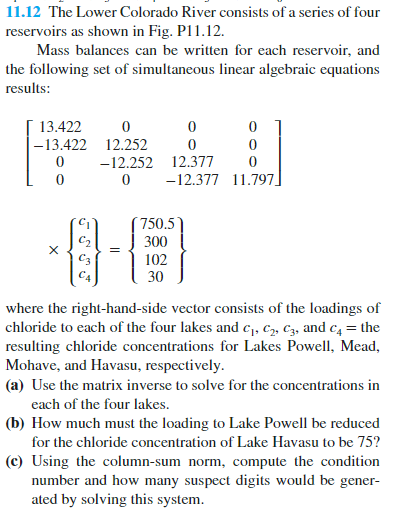

```python
import numpy as np

A = np.array([
    [13.422, 0, 0, 0],
    [-13.422, 12.252, 0,0],
    [0,-12.252,12.377,0],
    [0,0, -12.377, 11.797]
])
b = np.array([750.5, 300, 102, 30]).reshape(-1,1)

# (a)
A_inv = np.linalg.inv(A)
A_inv @ b
```

```
array([[ 55.91566086],
       [ 85.74110349],
       [ 93.11626404],
       [100.23734848]])
```

```python
A_inv
```

```
array([[0.07450454, 0.        , 0.        , 0.        ],
       [0.08161933, 0.08161933, 0.        , 0.        ],
       [0.08079502, 0.08079502, 0.08079502, 0.        ],
       [0.08476731, 0.08476731, 0.08476731, 0.08476731]])
```

```python
# (b)

target_diff = np.array([0,0,0,75 - (A_inv @ b)[3,0]]).reshape(-1, 1)
delta = np.linalg.solve(A_inv, target_diff)
target_c = A_inv @ (delta + b)
target_c
```

```
array([[55.91566086],
       [85.74110349],
       [93.11626404],
       [75.        ]])
```

```python
delta.round(4)
```

```
array([[   0.   ],
       [  -0.   ],
       [  -0.   ],
       [-297.725]])
```